# Joao M. Souto Maior

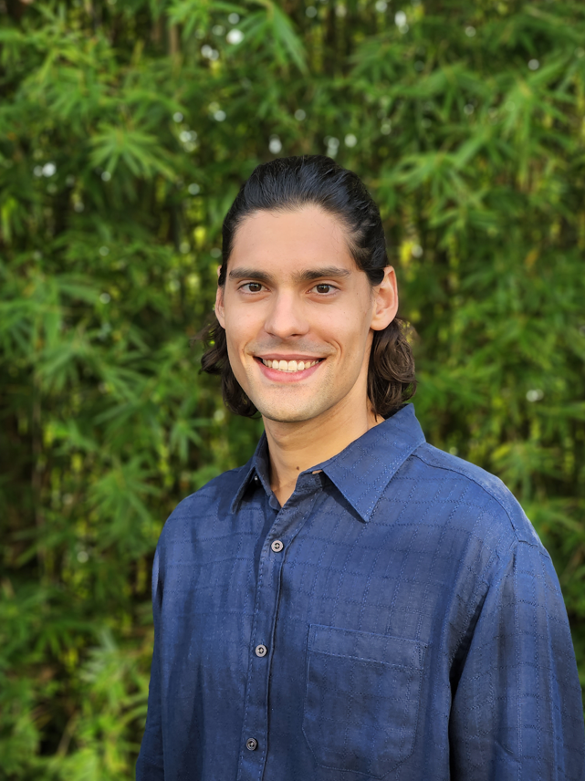

**PhD Candidate, Sociology of Education**  
Department of Applied Statistics, Social Science and Humanities at the New York University  
**Research interests**  
Computational methods; agent-based-modeling; school organization; within-school racial and socioeconomic inequalities.  
CV [GITHUB](https://github.com/joaosoutomaior/) [NYU PAGE](https://steinhardt.nyu.edu/joao-pedro-m-souto-maior)

### About

I am a fifth-year PhD student in the [Sociology of Education program](https://steinhardt.nyu.edu/programs/sociology-education) in the Department of Applied Statistics, Social Science and Humanities at New York University’s Steinhardt School of Culture, Education and Human Development. Broadly, I study the processes which shape unequal access to educational resources, particularly along dimensions of race and class. My current research investigates the formation of educational inequalities within educational institutions, with an emphasis on the role of organizational practices in producing these within-institution inequalities. I rely on a variety of quantitative methods, with an emphasis on agent-based modeling techniques, hoping to advance the use of computational methods—and the insights derived from it— within the fields of sociology of education and education policy.

I am originally from São Paulo, Brazil. I received my BA in economics from the University of Wisconsin-Madison in 2017. After my undergraduate studies, I started as an economics doctoral student at the CUNY Graduate Center, where I studied for a year before transferring to NYU.

*A note on names:* for publication purposes, I use a hyphenated version of my last name: João M. Souto-Maior

### Research

Working papers

Black-White advanced enrollment inequalities and the racial composition of schools: an agent-based modeling investigation  
Souto-Maior, J. *Expected submission: July, 2022*

Do AP enrollment processes favor certain racial groups? Measuring unjustified disparities in advanced course-taking in New York City high schools  
Souto-Maior, J. & Shroff, R. *Expected submission: June, 2022*

Determinants of race- and class-based educational inequalities within Brazilian high schools  
Souto-Maior, J. *Expected submission: July, 2022*  
[DASHBOARD](https://joaomsoutomaior.shinyapps.io/SaoPaulo_HighSchools_ENEM2019/)

Stepping out of the closet and into engagement: a quantitative analysis of outness, GSA engagement, and classroom engagement  
Sherwood, H., Souto-Maior, J., Poteat, P., Yoshikawa, H., Calzo, J. *Expected submission: Sep., 2022*  
[CODE](https://github.com/joaosoutomaior/outness-engagement-GSAs-code)

Conference presentations

Black-White advanced enrollment inequalities and the racial composition of schools: an agent-based modeling investigation  
Souto-Maior, J. *American Sociological Association: Session on Mathematical and Computational Approaches to Studying Inequality, Upcoming (August, 2022)*

Other presentations

Opportunity hoarding and Black-White inequalities in advanced enrollment: a simulation-based approach  
Souto-Maior, J. *Race and Ethnipaper Workshop, NYU’s Department of Sociology, February, 2021*

### Teaching

Discussion sections

Undergraduate Basic Statistics  
New York University — from Spring 2019 to Spring 2021  
[NOTES](https://bookdown.org/joao_msoutomaior/intro-stats-notes) SPRING 21

Qualitative Methods in International Education  
New York University — Spring 2022  
SPRING 22

Undergraduate seminars

URS Seminar: Research, Creative Work and the Public Good  
University of Wisconsin-Madison — 2016-17  
FALL 2016 SPRING 17

URS Seminar: Research and Creative Work at the Boundaries  
University of Wisconsin-Madison — 2015-16  
FALL 15 SPRING 16

### PhD study

PhD dissertation  
School racial integration and students’ academic experiences: a simulation-based study of Black-White course-taking inequalities

PhD coursework  
Areas of concentration: School organization; Quantitative methods  
COURSE LIST

Comprehensive oral exam  
READING LIST

Independent study: Black-White within-school achievement gaps  
READING LIST